# Analysis of the Seattle Seahawks from 2000-2024

Kelly Ariaza

## Introduction

The goal of this project is to explore the dataset to analyze the performance of the Seattle Seahawks from 2000–2024. This analysis can be used to understand how key performance metrics influence the team’s chances of making the playoffs and identify patterns that could inform future success.

The questions in this analysis include:

1. Has the Margin of Victory (MoV) improve or decline over the years?
2. How do playoff seasons differ from non-playoff seasons in terms of PF, PA, and SRS?

These will be the main questions answered and show how offensive strength, defensive consistency, and overall team quality (SRS) correlate with playoff likelihood, providing insights into what factors matter most for future performance.

## Data

### Structure

Reading in data set and making sure that all names are unique

```r
library(readr)
library(dplyr)
```

```r
library(ggplot2)


df <- read_csv(
  "seahawks",
  skip = 1,
  na = c("", "NA"),
  trim_ws = TRUE
)
names(df) <- make.names(names(df), unique = TRUE)

df <- df %>%
  rename(
    Pts_Off  = `Pts...14`,
    Yds_Off  = `Yds...15`,
    Pts_Def  = `Pts...16`,
    Yds_Def  = `Yds...17`
  )


df <- df %>%
  select(-AV, -Passer, -Rusher, -Receiver)
```

## Results

```r
df
```

```
## # A tibble: 25 × 22
##     Year     W     L     T Div..Finish Playoffs    PF    PA    PD Pts_Off
##    <dbl> <dbl> <dbl> <dbl> <chr>       <chr>    <dbl> <dbl> <dbl>   <dbl>
##  1  2024    10     7     0 2nd of 4    <NA>       375   368     7      18
##  2  2023     9     8     0 3rd of 4    <NA>       364   402   -38      17
##  3  2022     9     8     0 2nd of 4    Lost WC    407   401     6       9
##  4  2021     7    10     0 4th of 4    <NA>       395   366    29      16
##  5  2020    12     4     0 1st of 4    Lost WC    459   371    88       8
##  6  2019    11     5     0 2nd of 4    Lost Div   405   398     7       9
##  7  2018    10     6     0 2nd of 4    Lost WC    428   347    81       6
##  8  2017     9     7     0 2nd of 4    <NA>       366   332    34      11
##  9  2016    10     5     1 1st of 4    Lost Div   354   292    62      18
## 10  2015    10     6     0 2nd of 4    Lost Div   423   277   146       4
## # ℹ 15 more rows
## # ℹ 12 more variables: Yds_Off <dbl>, Pts_Def <dbl>, Yds_Def <dbl>, T.G <dbl>,
## #   Pts. <dbl>, Yds. <dbl>, out.of <dbl>, MoV <dbl>, SoS <dbl>, SRS <dbl>,
## #   OSRS <dbl>, DSRS <dbl>
```

### Has the Margin of Victory (MoV) improve or decline over the years?

```r
df <- df %>% mutate(
  MoV = as.numeric(MoV),
  Year = as.integer(Year),
)


df %>% select(Year, W, L, PF, PA, MoV) %>% head()
```

```
## # A tibble: 6 × 6
##    Year     W     L    PF    PA   MoV
##   <int> <dbl> <dbl> <dbl> <dbl> <dbl>
## 1  2024    10     7   375   368   0.4
## 2  2023     9     8   364   402  -2.2
## 3  2022     9     8   407   401   0.4
## 4  2021     7    10   395   366   1.7
## 5  2020    12     4   459   371   5.5
## 6  2019    11     5   405   398   0.4
```

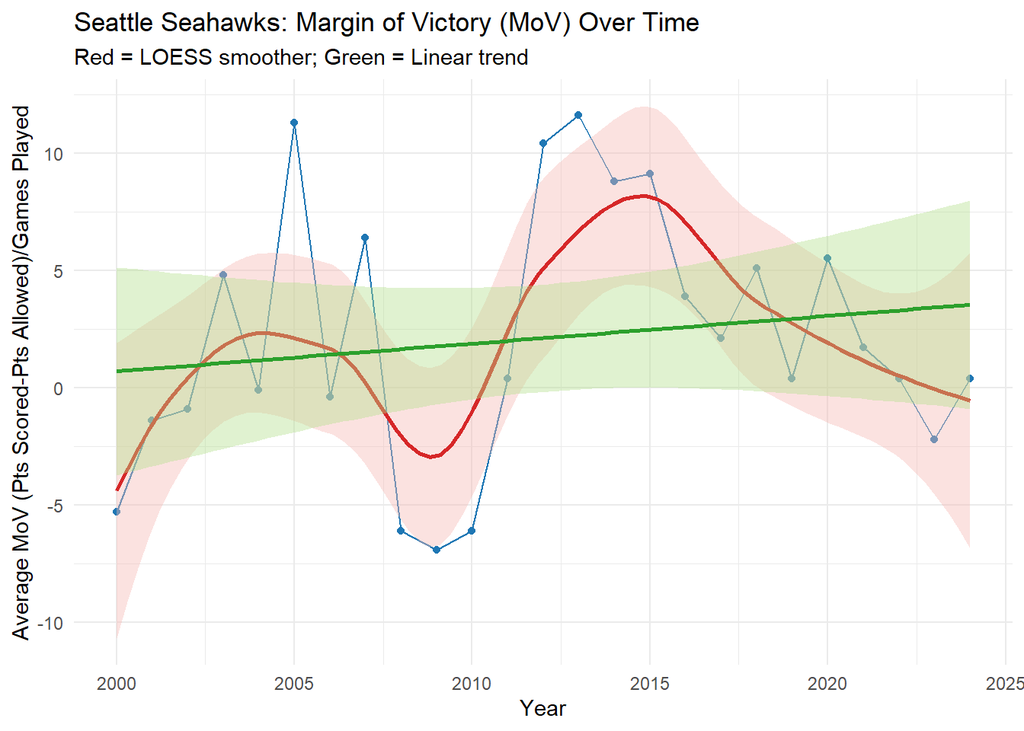

```r
ggplot(df, aes(x = Year, y = MoV)) +
  geom_line(color = "#1f77b4") +
  geom_point(color = "#1f77b4") +
  geom_smooth(method = "loess", span = 0.6, color = "#d62728", fill = "#f5b7b1") +
  geom_smooth(method = "lm", se = TRUE, color = "#2ca02c", fill = "#b2df8a") +
  labs(
    title = "Seattle Seahawks: Margin of Victory (MoV) Over Time",
    subtitle = "Red = LOESS smoother; Green = Linear trend",
    x = "Year", y = "Average MoV (Pts Scored-Pts Allowed)/Games Played"
  ) +
  theme_minimal()
```

```r
cor.test(df$Year, df$MoV, method = "spearman")
```

```
##
##  Spearman's rank correlation rho
##
## data:  df$Year and df$MoV
## S = 2014.8, p-value = 0.2793
## alternative hypothesis: true rho is not equal to 0
## sample estimates:
##      rho
## 0.225092
```

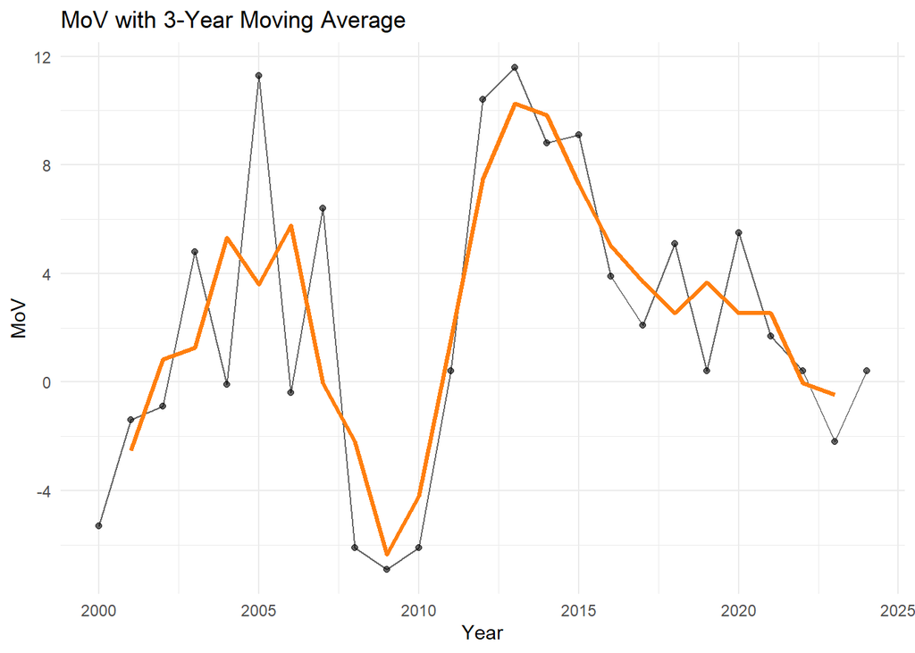

```r
# Centered 3-year moving average using stats::filter
df <- df %>%
  arrange(Year) %>%
  mutate(MoV_ma3 = as.numeric(stats::filter(MoV, rep(1/3, 3), sides = 2)))

ggplot(df, aes(Year, MoV)) +
  geom_point(alpha = 0.6) +
  geom_line(alpha = 0.6) +
  geom_line(aes(y = MoV_ma3), color = "#ff7f0e", linewidth = 1.2) +
  labs(title = "MoV with 3-Year Moving Average", x = "Year", y = "MoV") +
  theme_minimal()
```

```r
df <- df %>%
  mutate(era = case_when(
    Year <= 2009 ~ "2000s",
    Year <= 2019 ~ "2010s",
    TRUE ~ "2020s"
  ))

df %>%
  group_by(era) %>%
  summarise(
    n = n(),
    mean_MoV = mean(MoV, na.rm = TRUE),
    sd_MoV = sd(MoV, na.rm = TRUE)
  )
```

```
## # A tibble: 3 × 4
##   era       n mean_MoV sd_MoV
##   <chr> <int>    <dbl>  <dbl>
## 1 2000s    10    0.140   5.84
## 2 2010s    10    4.57    5.55
## 3 2020s     5    1.16    2.81
```

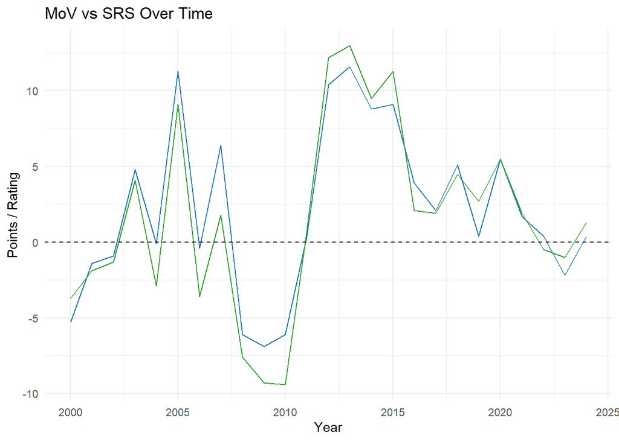

```r
ggplot(df, aes(Year)) +
  geom_line(aes(y = MoV), color = "#1f77b4") +
  geom_line(aes(y = SRS), color = "#2ca02c") +
  geom_hline(yintercept = 0, linetype = "dashed") +
  labs(title = "MoV vs SRS Over Time", x = "Year", y = "Points / Rating") +
  theme_minimal()
```

Second Question: How do playoff seasons differ from non-playoff seasons in terms of PF, PA, and SRS?

```r
library(scales)
library(tidyr)
```

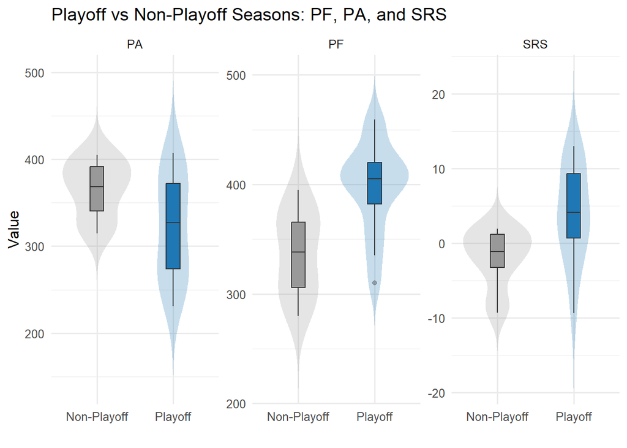

```r
playoff_years <- c(2003,2004,2005,2006,2007,2010,2012,2013,2014,2015,
                   2016,2018,2019,2020,2022)

df <- df %>%
  mutate(Playoff = if_else(Year %in% playoff_years, "Playoff", "Non-Playoff"))


df_long <- df %>%
  select(Year, Playoff, PF, PA, SRS) %>%
  pivot_longer(cols = c(PF, PA, SRS), names_to = "Metric", values_to = "Value")

ggplot(df_long, aes(x = Playoff, y = Value, fill = Playoff)) +
  geom_violin(trim = FALSE, alpha = 0.25, color = NA) +
  geom_boxplot(width = 0.18, outlier.alpha = 0.35, fatten = 0.8) +
  facet_wrap(~ Metric, scales = "free_y") +
  scale_fill_manual(values = c("Non-Playoff" = "#999999", "Playoff" = "#1f77b4")) +
  labs(
    title = "Playoff vs Non-Playoff Seasons: PF, PA, and SRS",
    x = "", y = "Value"
  ) +
  theme_minimal(base_size = 12) +
  theme(legend.position = "none")
```